# Negev Rain Annual slides

## 🌧️ Explore Annual Rainfall Patterns in Southern Israel

### 🔍 Overview

This project explores the annual rainfall patterns across twenty-six meteorological stations in Southern Israel, utilizing data from the [Israel Meteorological Service (IMS)](https://ims.gov.il/en/data_gov). The data was analyzed using Python and various libraries for statistical analysis and data visualization.

### 📊 Data and Web API

The project leverages rainfall data which can be explored through the provided Jupyter Notebook. You can also access the data and findings via the [Web API](https://ims.gov.il/en/ObservationDataAPI), but you will need a valid token to access it.

### 💬 Discussion

Analyzing rainfall data proves challenging when relying on a single trendline due to substantial correlation within the dataset. The data does not fit neatly into a linear trend, and different subsets of years lead to varying slopes in trendlines. This is visually demonstrated, as selecting different ranges of years can show either a positive or negative slope.

This study challenges the assumption that rainfall patterns are solely influenced by the time period chosen for measurements. By calculating all possible trendlines, the project captures the respective slopes over different time periods, allowing for a more comprehensive analysis. The heatmaps presented in the project visually represent these fluctuating slopes, revealing that rainfall amounts in southern Israel have generally declined over time.

While examining a 70-year span, the slope of the trendline varies significantly, but by focusing on periods of at least 10 years, a consistent downward trend emerges, marked by a predominant red hue, particularly in the upper corner. This suggests a clear and ongoing decrease in rainfall over time.

[📈 Tableau 📉](https://public.tableau.com/views/RainTrendAnalysisInSouthernIsrael/Story1?:language=en-US&:sid=&:redirect=auth&:display_count=n&:origin=viz_share_link)

## 🗺️ Rain Meteorological Stations Reference Map

An interactive map displaying rainfall measurement stations in the Israeli desert.  
📍 Hover to see station names in English, click to view them in Hebrew.  
🧭 Zoom and pan to explore!

Make this Notebook Trusted to load map: File -> Trust Notebook

[interactive chart not shown]

## 🌧️ Average Rainfall by Station — Regional Overview

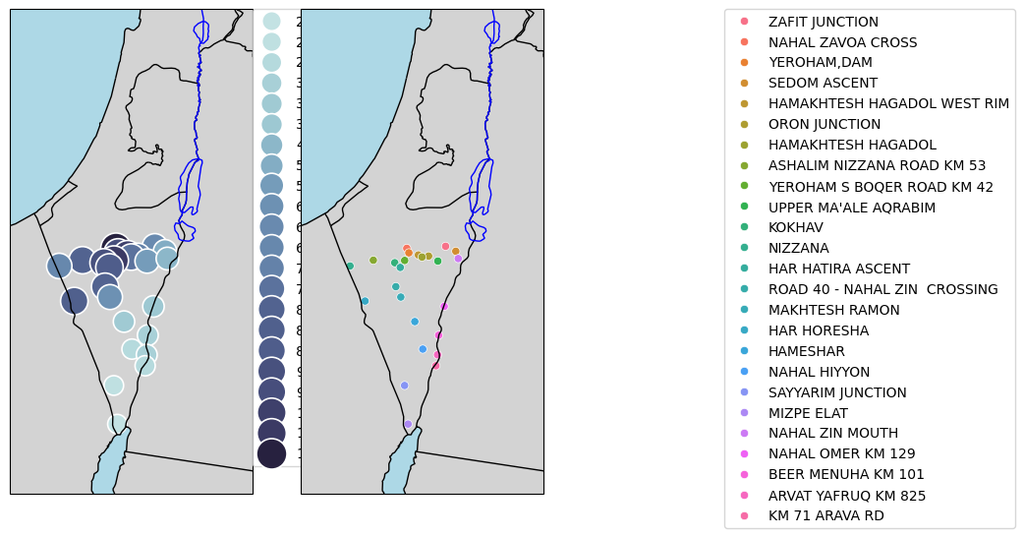

## 📈 Cumulative Rainfall Over Time by Station

This line plot shows how rainfall accumulates over the years at each station.  
⏳ Helps to compare long-term trends across the desert.  
🔁 Legend is reversed to highlight the latest series first.

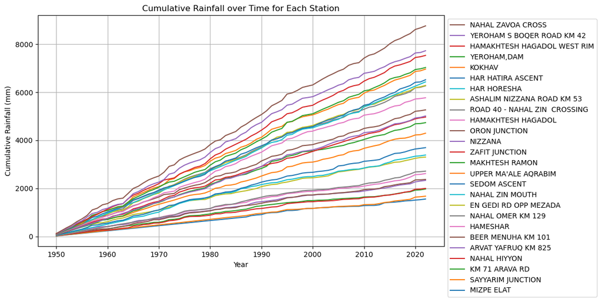

## ☔ Total Rainfall per Station Since 1949

A bar chart showing the cumulative rainfall recorded by each station.  
📊 Highlights which areas received the most or least precipitation over time.  
🌵 Useful for understanding long-term desert climate behavior.

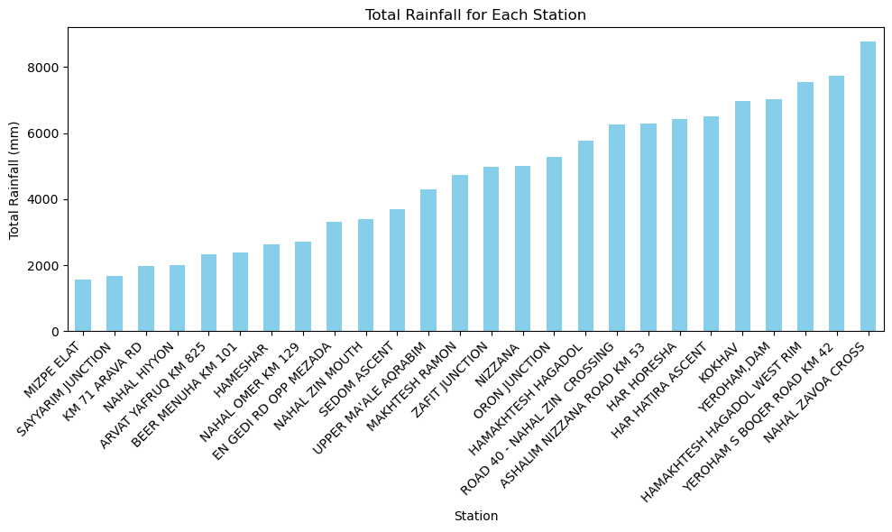

## 📦 Distribution of Rainfall per Station

Boxplots showing rainfall variability across stations.  
📉 Lower values are more common, while extreme values are rare.  
🧭 This helps visualize differences in desert sub-regions.

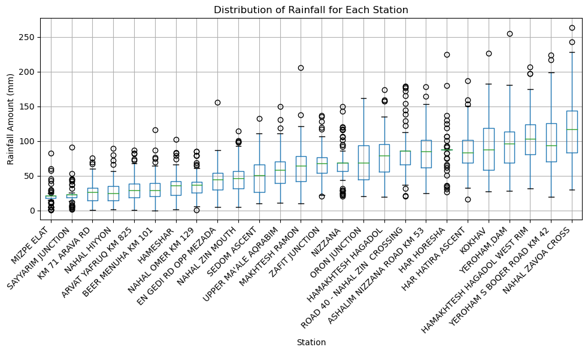

## 🎻 Violin Plots of Rainfall Distribution per Station

Violin plots show rainfall distributions per station, including summary stats and density curves.  
🌧️ Low rainfall values appear more frequently than high ones.  
📊 These plots are great for visualizing variability and skewness in desert precipitation.

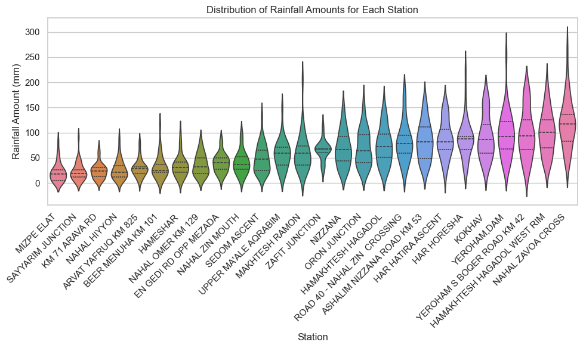

## 🌡️ Rainfall Patterns Across Stations and Years

A heatmap showing rainfall distribution across years and stations.  
📆 Easily spot wetter and drier years.  
🧪 Great for visualizing climatic trends over time.

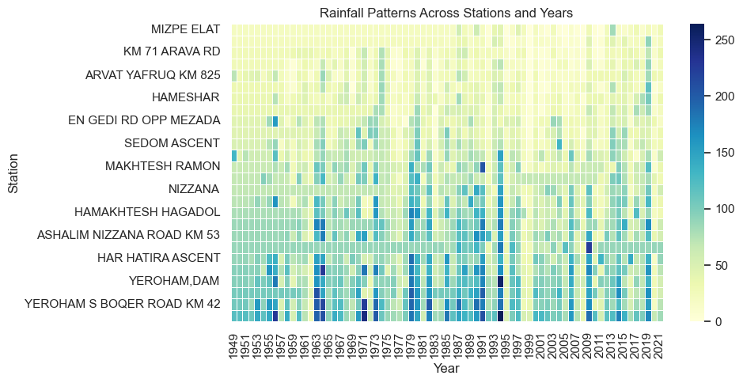

## 📉 Average vs. 5-Year Moving Average

This plot compares yearly rainfall with a 5-year moving average per station.  
🔍 It helps smooth short-term variations and highlight long-term rainfall trends.  
📆 Although the graph suggests a decreasing trend, it’s not clearly consistent.

[figure not shown]

## 📉 Trendlines of Yearly Rainfall Relative to the Average

By centering each time series around its average, we reveal underlying trends 📊.  
While most trendlines appear negative 📉, the result depends on the selected start and end year.  
To address this bias, we build a grid of individual linear trendlines per station 🚏.

[figure not shown]

## 🔥 Heatmap of Trendlines for Rainfall Data

This heatmap visualizes the trendlines between every two years of rainfall data, regardless of when the measurements started. Each cell in the heatmap represents the slope of the trendline between two years.

- **Blue cells** indicate years with higher rainfall, representing a positive trend (increasing rainfall).
- **Red cells** indicate years with lower rainfall, representing a negative trend (decreasing rainfall).
- The **top-left corner** represents the trendline for all the data combined.

### ✅ Conclusion:

As the measurement period extends, we observe a **decreasing trend** in rainfall over time.

[figure not shown]

## 📉 Heatmaps of Trendlines for Rainfall Data (10+ Years)

In this visualization, we analyze rainfall data by considering only measurements with a minimum of 10 years for more accurate results. We can observe a **general downward trendline** in the rainfall data across multiple stations.

### 🔍 What We Did:

- **Heatmaps** are generated for the first 20 stations, each representing the trendline slope between every two years.
- We use the **10-year minimum** rule to exclude stations with less data for more accuracy.

### ✅ Conclusion:

As we analyze the data over longer periods, we observe that the trend in most stations is **downward**, indicating a decrease in rainfall over time.

[figure not shown]

#### 📈 Cluster Map Correlation Heatmap Between Stations

This heatmap shows the correlation of rainfall patterns between different stations.

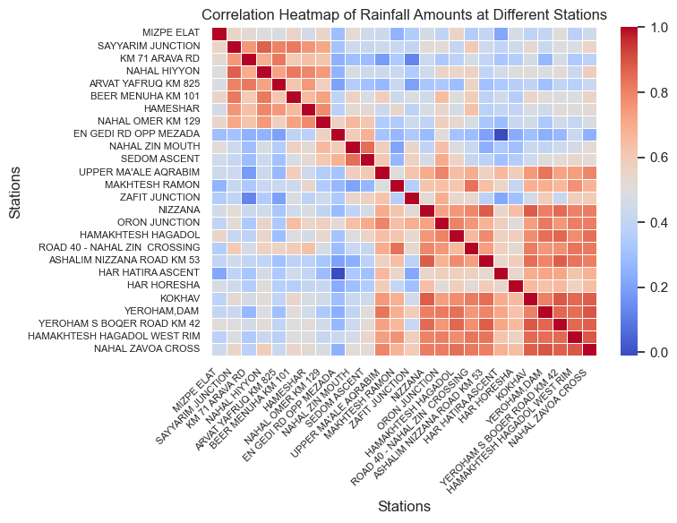